# FurtherSNVThings

Andy Lynch

21 July 2016

# Mutational contexts

## Preliminaries

First we will load the libraries that we are going to require. These are *BSgenome.Hsapiens.UCSC.hg19* (which contains the reference genome from which we are going to extract contexts), *SomaticSignatures* (which has the context-extracting functions), and *deconstructSigs* (which does the signature deconstruction work).

```r
suppressWarnings(suppressMessages(library(SomaticSignatures,quietly=T,warn.conflicts = F)))
suppressWarnings(suppressMessages(library(BSgenome.Hsapiens.UCSC.hg19,quietly=T,warn.conflicts = F)))
suppressWarnings(suppressMessages(library(deconstructSigs,quietly=T,warn.conflicts = F)))
```

## Loading in data

Now read in the vcf file, and keep just the autosomes and sex chromosomes (which we have to rename to match the bioconductor reference genome). Note that on my machine at least, I have to change all references to FTX in the vcf file to something else (I chose FUX), for the function to work. **I have no idea why!**

```r
vcf<-readVcfAsVRanges("HCC1143_vs_HCC1143_BL.flagged.muts.edited.vcf","hg19",use.names=T)
vcf<-keepSeqlevels(vcf,c("1","2","3","4","5","6","7","8","9","10","11","12","13","14","15","16","17","18","19","20","21","22","X","Y"))
seqlevels(vcf)<-c("chr1","chr2","chr3","chr4","chr5","chr6","chr7","chr8","chr9","chr10","chr11","chr12","chr13","chr14","chr15","chr16","chr17","chr18","chr19","chr20","chr21","chr22","chrX","chrY")
```

The VRanges object contains two rows for each SNV (one for the control and one for the tumour), so we just take the bottom half. We will also remove anything failing the soft filters.

```r
vcf<-vcf[92284:184566]
vcf<-vcf[apply(vcf@softFilterMatrix,1,prod)==1]
```

## Get mutational contexts

We can obtain the mutational context for each SNV quite conveniently.

```r
mc<-mutationContext(vcf,BSgenome.Hsapiens.UCSC.hg19)
```

## Annoying data manipulation

However the context info is stored as two variables: the alteration in the form “XY”, and the context in the form “W.Z”. We will now reformat the contexts to match the signature data (i.e. putting them in the form “W[X>Y]Z”). This we do using the “subseq” command to extract the characters we want, and “paste” to paste them together in the form we want. See ?subseq and ?paste for details.

```r
SMT<-paste(
  subseq(elementMetadata(mc)$context,1,1),
  rep("[",length(mc)),
  subseq(elementMetadata(mc)$alteration,1,1),
  rep(">",length(mc)),
  subseq(elementMetadata(mc)$alteration,2,2),
  rep("]",length(mc)),
  subseq(elementMetadata(mc)$context,3,3),
  sep="")
```

```r
SMT<-factor(SMT,levels=colnames(signatures.cosmic))
```

Now we need to tabulate the mutation/context combinations and shape it for the package that follows. Apologies that this is inelegant.

```r
SMTdf<-as.data.frame(t(matrix(table(SMT))))
colnames(SMTdf)<-colnames(signatures.cosmic)
rownames(SMTdf)<-1
```

## Signatures

Before going further we can have a look at the mutation numbers, ignoring contexts

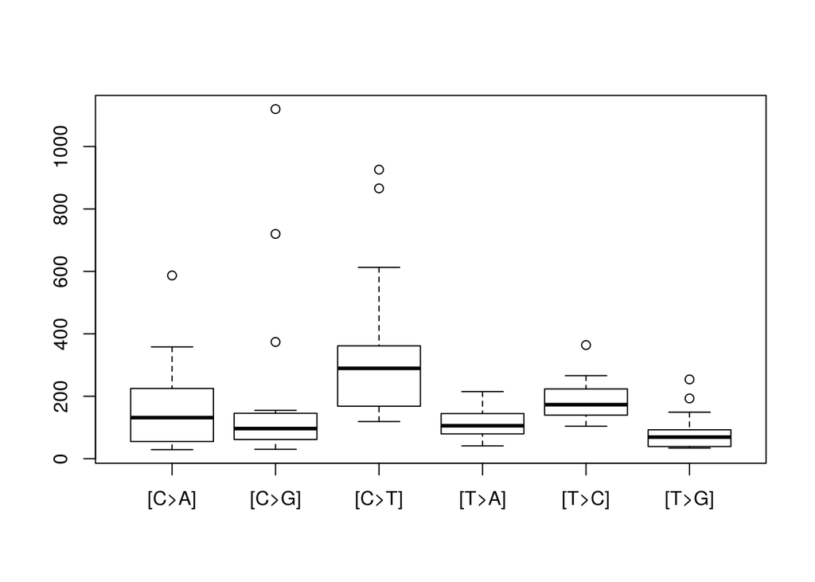

```r
boxplot(unlist(SMTdf)~sapply(colnames(SMTdf),substr,2,6))
```

Having seen that transitions are dominating, we can pull out the signatures.

```r
sigs<-whichSignatures(tumor.ref =SMTdf,
                                signatures.ref = signatures.cosmic,
                                sample.id = 1, contexts.needed = TRUE)

sigs$weight
```

```
##   Signature.1 Signature.2 Signature.3 Signature.4 Signature.5 Signature.6
## 1    0.106255  0.07533352   0.2992757           0           0           0
##   Signature.7 Signature.8 Signature.9 Signature.10 Signature.11
## 1           0  0.06038059  0.09385184            0            0
##   Signature.12 Signature.13 Signature.14 Signature.15 Signature.16
## 1            0    0.1273581            0            0     0.100189
##   Signature.17 Signature.18 Signature.19 Signature.20 Signature.21
## 1            0            0            0            0            0
##   Signature.22 Signature.23 Signature.24 Signature.25 Signature.26
## 1            0            0            0            0            0
##   Signature.27 Signature.28 Signature.29 Signature.30
## 1            0            0            0            0
```

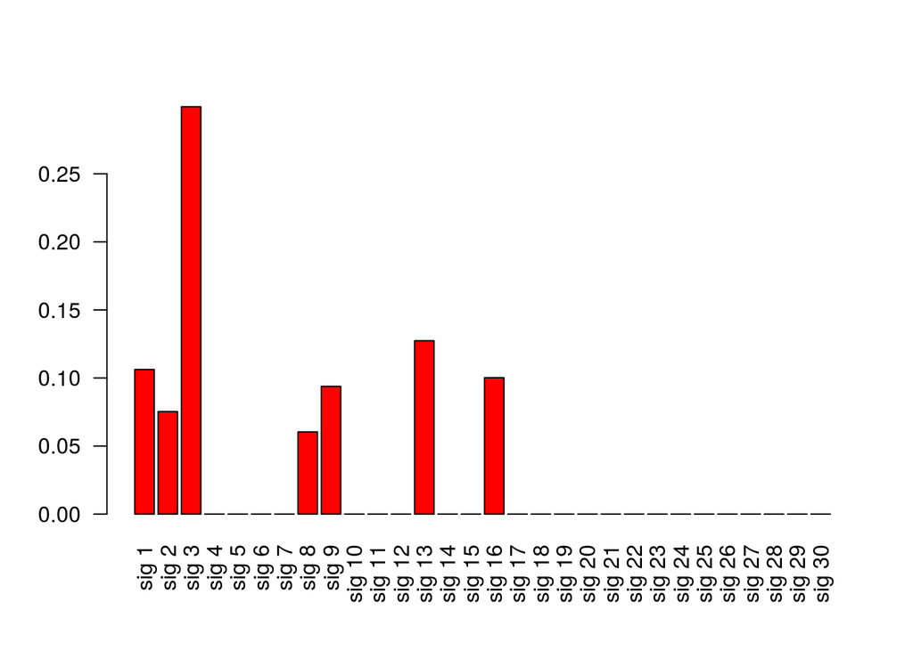

```r
barplot(unlist(sigs$weight),las=2,col="red",names=paste("sig",1:30))
```

Which signature dominates? Compare to the list at http://cancer.sanger.ac.uk/cosmic/signatures and decide whether this is as expected.

# MNVs

We will now take a quick look at the multiple nucleotide variants in the vcf. These manifest as consecutive bases represented in consecutive rows of the file.

## Identify starts of runs of consecutive entries.

The *diff* command reports the difference between consecutive entries in the file. Consecutive bases will have locations that differ by 1. The second line here ensures that only the first entry in a run is returned.

```r
MNVindex<-which(diff(ranges(mc)@start)==1)
MNVindex<-MNVindex[-(which(diff(MNVindex)==1)+1)]
```

## Identify mutations

We can extract the sequences of each run. Note that we can’t simply paste together the mutations as reported, because strand information may be lost. e.g. if we have CG>TA both positions will be reported as C>T.

```r
MNV<-rep("",275)
for(i in 1:275){
mnvlength<-max(which(ranges(mc)@start[MNVindex[i]+1:100]-ranges(mc)@start[MNVindex[i]]==1:100))
MNV[i]<-paste(paste(mc@ref[MNVindex[i]+(0:mnvlength)],collapse=""),">",paste(mc@alt[MNVindex[i]+(0:mnvlength)],collapse=""),collapse="",sep="")
}
```

## Look at the MNVs

Note that we haven’t collapsed equivalent mutations (e.g. TT>AA and AA>TT) into one entry for this object. Which MNVs are most prevalent? Of what might they be indicative?

```r
tail(sort(table(MNV)))
```

```
## MNV
## TC>AA CC>AA CA>TG TG>CA CC>TT GG>AA
##     5     8    18    19    21    23
```

## Credulity test

One MNV appears to be TGTG>CCCT. It is located at chr5:134119386-134119389. Look at this area in IGV and decide whether you believe it.